# Predictive model using ridgereg

Trung and Camilia

2015-10-13

### 1. Load library and dataset

```r
library(linregpackage)
library(mlbench)
library(caret)
data(BostonHousing)
attach(BostonHousing)
head(BostonHousing, 5)
```

```
##      crim zn indus chas   nox    rm  age    dis rad tax ptratio      b
## 1 0.00632 18  2.31    0 0.538 6.575 65.2 4.0900   1 296    15.3 396.90
## 2 0.02731  0  7.07    0 0.469 6.421 78.9 4.9671   2 242    17.8 396.90
## 3 0.02729  0  7.07    0 0.469 7.185 61.1 4.9671   2 242    17.8 392.83
## 4 0.03237  0  2.18    0 0.458 6.998 45.8 6.0622   3 222    18.7 394.63
## 5 0.06905  0  2.18    0 0.458 7.147 54.2 6.0622   3 222    18.7 396.90
##   lstat medv
## 1  4.98 24.0
## 2  9.14 21.6
## 3  4.03 34.7
## 4  2.94 33.4
## 5  5.33 36.2
```

Then, we split the dataset:

```r
# Rule of thumb: 60% for training, 40% for testing
index <- 1:nrow(BostonHousing)
set.seed(12082518)
inTraining <- createDataPartition(BostonHousing$medv, p = .60, list = FALSE)
trainset <- BostonHousing[ inTraining,]
testset  <- BostonHousing[-inTraining,]
print(nrow(trainset))
```

```
## [1] 306
```

```r
print(nrow(testset))
```

```
## [1] 200
```

### 2. Fit a linear regression model and a fit a linear regression model with forward selection of covariates on the training dataset.

First simple overfitted linear model:

```r
lmfit <- train(medv ~ ., data = trainset,
               method = "lm")
print(lmfit)
```

```
## Linear Regression
##
## 306 samples
##  13 predictor
##
## No pre-processing
## Resampling: Bootstrapped (25 reps)
## Summary of sample sizes: 306, 306, 306, 306, 306, 306, ...
## Resampling results
##
##   RMSE      Rsquared   RMSE SD    Rsquared SD
##   5.025099  0.7041593  0.5940222  0.0792598
##
##
```

Next, the model using forward selection:

```r
lmforward = train(medv ~ ., data = trainset,
                 method = "leapForward")
print(lmforward)
```

```
## Linear Regression with Forward Selection
##
## 306 samples
##  13 predictor
##
## No pre-processing
## Resampling: Bootstrapped (25 reps)
## Summary of sample sizes: 306, 306, 306, 306, 306, 306, ...
## Resampling results across tuning parameters:
##
##   nvmax  RMSE      Rsquared   RMSE SD    Rsquared SD
##   2      5.381918  0.6633700  0.6216038  0.06615297
##   3      5.185657  0.6861530  0.6375208  0.06098075
##   4      5.097917  0.6954383  0.6072429  0.06063160
##
## RMSE was used to select the optimal model using  the smallest value.
## The final value used for the model was nvmax = 4.
```

We can see that with *lmfit* the model provide better fitting, but with high number of parameters, this model will have low generalization ability and overfitting training data.

Conversely, *lmforward* selected 4 parameters give reasonable good RMSE, which is **5.097917**. From this point of view, 9 more parameters included in *lmfit* may only explained **0.072** RMSE value.

### 3. Fit a ridge regression model using your ridgereg() function to the training dataset for diffrent values of $\lambda$.

```r
modelinfo = list(
  library=c('linregpackage'),
  type=c("Regression"),
  parameters=data.frame(parameter = c("lambda"),
                        class = c("numeric"),
                        label = c("Lambda")),
  fit=function(x, y, wts, param, lev, last, weights, classProbs, ...){
    fitted= (ridgereg(y~x, data=NULL, param))
    return(fitted)
  },
  predict=function(modelFit, newdata, preProc = NULL, submodels = NULL){
    predictions = predict(modelFit, newdata)
    return(predictions)
  },
  grid=function(x, y, len = NULL, search = "grid"){
    return (data.frame(lambda=seq(0,1000,50)/1000))
  },
  prob=NULL
)
fitControl <- trainControl(## 10-fold CV
                           method = "repeatedcv",
                           number = 10,
                           ## repeated ten times
                           repeats = 10)
lmridge = train(medv ~ ., data = trainset,
                method = modelinfo,
                trControl=fitControl)
print(lmridge)
```

```
## 306 samples
##  13 predictor
##
## No pre-processing
## Resampling: Cross-Validated (10 fold, repeated 10 times)
## Summary of sample sizes: 275, 275, 276, 275, 274, 276, ...
## Resampling results across tuning parameters:
##
##   lambda  RMSE      Rsquared   RMSE SD   Rsquared SD
##   0.00    4.847806  0.7271484  1.116995  0.1170180
##   0.05    4.846155  0.7272758  1.132137  0.1186513
##   0.10    4.847601  0.7270889  1.143524  0.1199086
##   0.15    4.850469  0.7267600  1.152327  0.1208989
##   0.20    4.853933  0.7263734  1.159288  0.1216944
##   0.25    4.857577  0.7259714  1.164900  0.1223442
##   0.30    4.861189  0.7255757  1.169496  0.1228824
##   0.35    4.864661  0.7251967  1.173310  0.1233336
##   0.40    4.867945  0.7248392  1.176512  0.1237157
##   0.45    4.871022  0.7245049  1.179227  0.1240422
##   0.50    4.873890  0.7241936  1.181548  0.1243233
##   0.55    4.876556  0.7239046  1.183546  0.1245669
##   0.60    4.879030  0.7236365  1.185278  0.1247792
##   0.65    4.881327  0.7233878  1.186786  0.1249650
##   0.70    4.883458  0.7231570  1.188106  0.1251285
##   0.75    4.885439  0.7229426  1.189266  0.1252727
##   0.80    4.887281  0.7227433  1.190288  0.1254003
##   0.85    4.888996  0.7225578  1.191193  0.1255136
##   0.90    4.890595  0.7223848  1.191994  0.1256143
##   0.95    4.892087  0.7222234  1.192706  0.1257040
##   1.00    4.893482  0.7220725  1.193339  0.1257840
##
## RMSE was used to select the optimal model using  the smallest value.
## The final value used for the model was lambda = 0.05.
```

Without crossvalidation, the model with $\lambda=0$ will give the best RMSE, however, *caret* with a strategy of tuning parameter selects $\lambda=0.05$ as the best option.

It is reasonable value, since too big $\lambda$ can make the model underfit, and smaller $\lambda$ will overfit the training data.

### 4. Comparison of 3 models

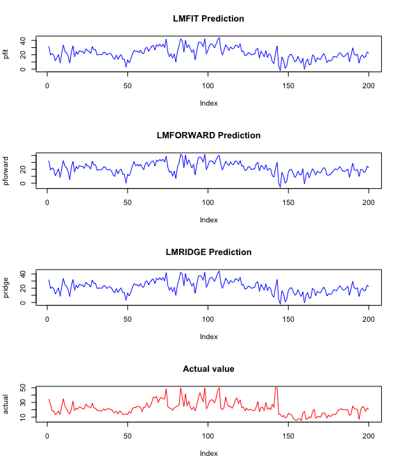

```r
pfit = predict(lmfit, testset)
pforward = predict(lmforward, testset)
pridge = predict(lmridge, testset)
actual = testset$medv
par(mfrow=c(4,1))
plot(pfit,type='l',col='blue',main="LMFIT Prediction")
plot(pforward,type='l',col='blue',main="LMFORWARD Prediction")
plot(pridge,type='l',col='blue',main="LMRIDGE Prediction")
plot(actual, type='l', col='red',main="Actual value")
```

Conversele, the RMSE can give more clearly results:

```r
print(paste('RMSE lmfit:', sqrt(sum((actual-pfit)^2)/length(actual)) ))
```

```
## [1] "RMSE lmfit: 4.9462015699261"
```

```r
print(paste('RMSE lmforward:', sqrt(sum((actual-pforward)^2)/length(actual)) ))
```

```
## [1] "RMSE lmforward: 5.54486356980504"
```

```r
print(paste('RMSE ridge:', sqrt(sum((actual-pridge)^2)/length(actual)) ))
```

```
## [1] "RMSE ridge: 4.97103850402763"
```

From this point of view, *lmfit*, a model with full 14 parameters give the best fit. The result seem to be inplausible, since a big model gives very poor generalization. However, the result on testset can be considered as reliable and this is a **helpful** model.